# Chương 2. Biến ngẫu nhiên

$\hspace{9cm}$ PGS.TS. Lê Xuân Trường

**Nội dung**

- Khái niệm về biến ngẫu nhiên
- Phân phối xác suất của biến ngẫu nhiên
  - Hàm phân phối xác suất tích lũy
  - Bảng phân phối xác suất của biến ngẫu nhiên rời rạc
  - Hàm mật độ xác suất của biến ngẫu nhiên liên tục
- Một số đặc trưng của biến ngẫu nhiên
  - Kỳ vọng
  - Phương sai
  - Mode và trung vị
- Các phân phối xác suất quan trọng

### Khái niệm biến ngẫu nhiên

Giả sử $\Omega$ là một không gian mẫu của một thí nghiệm ngẫu nhiên.

**Định nghĩa 1** $\,\,$ Mỗi hàm số $X : \Omega \to \mathbb{R}$ được gọi là biến ngẫu nhiên trên $\Omega$.

- Biến ngẫu nhiên rời rạc: $\,\,$ tập giá trị của $X$ là một tập hữu hạn hoặc đếm được
- Biến ngẫu nhiên liên tục: $\,\,$ tập giá trị của $X$ là một tập vô hạn không đếm được

**Ví dụ 1**

Trong một cái túi có 1 bi đỏ và 99 bi đen. Người chơi cần bỏ ra 10000 đồng để lấy ngẫu nhiên 1 bi. Nếu lấy trúng bi đỏ thì được thưởng 100000 đồng. Nếu lấy trúng bi đen thì không được thưởng. Gọi $X$ là số tiền mà người chơi có sau 1 lần lấy bi. Khi đó $X$ là một biến ngẫu nhiên rời rạc nhận các giá trị 90000 và -10000.

**Ví dụ 2**

Trong một trò chơi, người chơi tung một đồng xu. Nếu xuất hiện mặt sấp thì người đó được một đồng, xuất hiện mặt ngửa thì mất một đồng. Gọi $X$ là số tiền người chơi có được sau $n$ lần chơi. Khi đó $X$ là một biến ngẫu nhiên rời rạc, nhận các giá trị nguyên trong khoảng $[-n, n]$.

**Ví dụ 3** $\,\,$ Gọi $Y$ là nhiệt độ trong một ngày. Khi đó $Y$ là một số ngẫu nhiên liên tục nhận giá trị từ $-90^oC$ đến $71^oC.$

(*Năm 1983, nhiệt độ thấp kỷ lục từng được ghi nhận tại trạm Vostok là $-89,2^oC.$ Sa mạc Lut tại Iran là vùng đất nóng nhất trên Trái đất với nhiệt độ lên tới $70,7^o C$ vào năm 2005*)

### Phân phối xác suất của biến ngẫu nhiên

**Định nghĩa 2** $\,\,$ Cho $\Omega$ là không gian mẫu của một thí nghiệm ngẫu nhiên và $P$ là độ đo xác suất trên $\Omega$. Nếu $X$ là một biến ngẫu nhiên trên $\Omega$ thì hàm số $$ F : \mathbb{R} \to [0, 1] $$ $$ F_X(x) = P(\{\omega \in \Omega \,:\, X(\omega) \leq x\}), \,x \in \mathbb{R} ,$$ được gọi là **hàm phân phối xác suất tích lũy** của biến ngẫu nhiên $X$.

**Chú ý 1** $\,\,$ Ta có thể thấy rằng hàm phân phối xác suất tích lũy $F_X$ có các tính chất sau

- $F_X$ là hàm không giảm
- $F_X(-\infty) = 0$ và $F_X(\infty) = 1$

**Định nghĩa 3 (Bảng phân phối xác suất của biến ngẫu nhiên rời rạc)** $\,\,$ Cho $X$ là một biến ngẫu nhiên rời rạc trên không gian mẫu $\Omega$ với tập giá trị $$ \{x_1, x_2, ..., x_k, \ldots\} $$ Bảng được xác định như dưới đây, trong đó $p_k = P(X = x_k)$, được gọi là **bảng phân phối xác suất** của $X$:

| $X$ | $x_1$ | $x_2$ | $\cdots$ | $x_k$ | $\cdots$ |
| --- | --- | --- | --- | --- | --- |
| $P(X = x_k)$ | $p_1$ | $p_2$ | $\cdots$ | $p_k$ | $\cdots$ |

**Chú ý 2** $\,\,$ Từ các định nghĩa trên ta có thể suy ra mối liên hệ giữa hàm phân phối xác suất tích lũy và bảng phân phối xác suất của biến ngẫu nhiên rời rạc. Cụ thể như sau

- Hàm phân phối xác suất tích lũy có thể được xác định từ bảng phân phối xác suất $$ F_X(x) = \sum\limits_{i=1}^n p_i \quad \text{nếu} \,\, x_{n-1} \leq x < x_n $$
- Ngược lại ta có $\,\, p_i = F(x_i) - F(x_{i-1})$

**Ví dụ 4** $\,\,$ Gọi $X$ là số chấm xuất hiện khi tung xúc sắc. Xác định bảng phân phối xác suất và hàm phân phối xác suất tích lũy của $X$.

**Ví dụ 5** $\,\,$ Một xạ thủ chỉ có 3 viên đạn. Anh ta được yêu cầu bắn từng phát cho đến khi trúng mục tiêu thì dừng bắn, biết rằng xác suất trúng của mỗi lần bắn là 0,6. Hãy lập bảng phân phôi xác suất và hàm phân phối xác suất tích lũy của số đạn cần bắn.

**Ví dụ 6** $\,\,$ Gieo một con xúc xắc và gọi $X$ là số lần gieo đến khi gặp mặt 6 chấm. Lập bảng phân phối xác suất của $X$.

**Ví dụ 7** $\,\,$ Có hai lô hàng: lô 1 có 10 sản phẩm trong đó có 3 sản phẩm loại A; lô 2 có 12 sản phẩm trong đó có 4 sản phẩm loại A.

- Lấy ngẫu nhiên mỗi lô một sản phẩm. Gọi $X$ là số sản phẩm loại A lấy được. Lập bảng phân phối xác suất của $X$
- Chọn ngẫu nhiên một lô hàng, từ đó lấy ngẫu nhiên 3 sản phẩm. Đặt $Y$ là số sản phẩm loại A lấy được. Lập bảng phân phối xác suất của $Y$.

$$ P(X = 0) = \frac{C^1_{7}}{C^1_{10}}.\frac{C^1_{8}}{C^1_{12}} = \frac{7}{15}, \quad P(X = 1) = \frac{C^1_{3}}{C^1_{10}}.\frac{C^1_{8}}{C^1_{12}} + \frac{C^1_{7}}{C^1_{10}}.\frac{C^1_{4}}{C^1_{12}} = \frac{13}{30}, \quad P(X = 2) = \frac{C^1_{3}}{C^1_{10}}.\frac{C^1_{4}}{C^1_{12}} = \frac{1}{10} $$

**Định ngĩa 3 (Hàm mật độ xác suất của biến ngẫu nhiên liên tục)** $\,\,$ Cho $X$ là một biến ngẫu nhiên liên tục trên không gian mẫu $\Omega$. Một hàm số $f_X$ thỏa các tính chất sau

- $f_X(x) \geq 0$
- $\displaystyle \int_{-\infty}^\infty f_X(x)dx = 1$
- $P(a \leq X \leq b) = \displaystyle \int_a^b f_X(x)dx$

được gọi là hàm mật độ xác suất của biến ngẫu nhiên $X$.

$\hspace{7cm}$

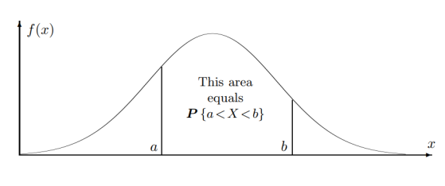

**Chú ý 3** $\,\,$ Tương tự trường hợp biến ngẫu nhiên rời rạc, có mối liên hệ giữa hàm mật độ xác suất và hàm phân phối xác suất tích lũy của biến ngẫu nhiên $X$ như sau

- Với mọi $x \in \mathbb{R}$ ta có $F_X(x) = \displaystyle \int_{-\infty}^x f_X(y)dy$
- Nếu $F_X$ là hàm số khả vi, ta có $f_X(x) = F_X'(x)$

**Chú ý 4** $\,\,$ Nếu $X$ là một biến ngẫu nhiên liên tục với hàm mật độ là $f_X$ thì ta có $P(X = a) = \displaystyle \int_a^a f_X(x)dx = 0$.

**Ví dụ 8** $\,\,$ Thời gian sử dụng của một thiết bị điện tử (tính bằng năm) là một biến ngẫu nhiên liên $X$ có hàm mật độ $$ f_X(x) = \begin{cases} kx^{-3} & \text{nếu} \,\, x \geq 1, \\ 0 & \text{nếu} \,\, x < 1. \end{cases} $$

- Tìm hàm phân phối xác suất tích lũy của $X$
- Tính xác suất thiết bị đó sử dụng được hơn 5 năm

**Ví dụ 9** $\,\,$ Thời gian phục vụ mỗi khách hàng tại một cửa hàng là một biến ngẫu nhiên liên tục $X$ (tính bằng phút) có hàm mật độ xác suất như sau $$ f_X(x) = \begin{cases} ke^{-4x} & \text{nếu} \,\, x > 0, \\ 0 & \text{nếu} \,\, x \leq 0. \end{cases} $$

- Tìm hàm phân phối xác suất tích lũy của $X$
- Tính xác suất thời gian phục vụ một khách hàng trong khoảng thời gian từ 1 đến 2 phút

**Ví dụ 10** $\,\,$ Gọi $X$ là thời gian sử dụng của một loại pin (tính bằng năm). Giả sử hàm mật độ xác suất của $X$ được cho bởi $$ f_X(x) = \begin{cases} 0,5e^{-0,5x} & \text{nếu} \,\, x > 0, \\ 0 & \text{nếu} \,\, x \leq 0. \end{cases} $$

- Tính xác suất để loại pin này sử dụng được ít hơn 2 năm hoặc nhiều hơn 4 năm
- Giả sử có một viên pin loại này đã được sử dụng 2 năm. Tính xác suất để pin này được sử dụng ít nhất 3 năm.

**Ví dụ 11** $\,\,$ Gọi $X$ là thời gian (tháng) sử dụng của một loại thiết bị điện tử. Giả sử biến ngẫu nhiên $X$ có hàm phân phối xác suất tích lũy $$ F_X(x) = \begin{cases} 1- e^{-0,03x^{1,2}} & \text{nếu} \,\, x > 0, \\ 0 & \text{nếu} \,\, x \leq 0. \end{cases} $$

- Chọn ngẫu nhiên một thiết bị. Tính xác suất thiết bị đó sử dụng được ít nhất 12 tháng.
- Tìm hàm mật độ xác suất của $X$

### Một số đặc trưng của biến ngẫu nhiên

**Định nghĩa 4** $\,\,$ **Kỳ vọng (Expected)** của một biến ngẫu nhiên $X$ là một số được xác định như sau

- Nếu $X$ là rời rạc với tập giá trị $\{x_1, x_2, \ldots\}$ thì $$ \mu_X \equiv E(X) := \sum\limits_{i\geq 1}x_iP(X = x_i) $$
- Nếu $X$ là liên tục với hàm mật độ xác suất là $f_X$ thì $$ \mu_X \equiv E(X) := \int_{-\infty}^\infty xf_X(x)dx $$

**Chú ý 5** $\,\,$ Kỳ vọng của biến ngẫu nhiên là giá trị trung bình có trọng số của tất các các giá trị của biến ngẫu nhiên đó.

**Định nghĩa 5** $\,\,$ **Phương sai (Variance)** của một biến ngẫu nhiên $X$ là đại lượng đo lường sự phân tán của biến ngẫu nhiên so với giá trị kỳ vọng, và được xác định như sau

- Nếu $X$ là rời rạc với tập giá trị $\{x_1, x_2, \ldots\}$ thì $$ \sigma_X^2 \equiv Var(X) := E[(X - \mu_X)^2] = \sum\limits_{i\geq 1}(x_i -\mu_X)^2P(X_i = x_i) $$
- Nếu $X$ là liên tục với hàm mật độ xác suất là $f_X$ thì $$ \sigma_X^2 \equiv Var(X) := E[(X - \mu_X)^2] = \int_{-\infty}^\infty (x - \mu_X)^2f_X(x)dx $$

**Chú ý 6** $\,\,$ Căn bậc hai của phương sai được gọi là **độ lệch chuẩn (standard deviation)** của biến ngẫu nhiên

**Định nghĩa 6** $\,\,$ **Mode** của một biến ngẫu nhiên $X$ là một số thực $\alpha$ sao cho

- $P(X = \alpha) = \max\{P(X = x_i) \,:\, i = 1, 2, \ldots\}$ trong trường hợp $X$ là rời rạc với tập giá trị là $\{x_1, x_2, \ldots\}$
- $f_X(\alpha) = \max \{f_X(x) \,:\, x \in \mathbb{R}\}$ nếu $X$ là biến ngẫu nhiên liên tục với hàm mật độ xác suất $f_X$

**Ví dụ 12** $\,\,$ Trong một hộp có $99$ tấm thẻ đen và $1$ tấm thẻ đỏ. Mỗi lần rút thẻ người chơi sẽ phải trả $1000$ đồng. Nếu rút trúng thẻ màu đỏ thì người chơi được thưởng $100000$ đồng. Gọi $X_n$ là số tiền người chơi đạt được sau $n$ lần rút (sau mỗi lần rút tấm thẻ được bỏ lại vào trong hộp).

- Tính $E(X_1)$, $Var(X_1)$ và Mod($X_1$)
- Tính $E(X_2)$, $Var(X_2)$ và Mod($X_2$)

**Ví dụ 13** $\,\,$ Gọi $X$ là khối lượng cát (tính bằng tấn) do một công ty bán ra hàng tuần. Giả sử biến ngẫu nhiên $X$ có hàm mật độ xác suất như sau $$ f_X(x) = \begin{cases} 1,5(1- x^2) & \text{nếu} \,\, 0 \leq x \leq 1, \\ 0 & \text{nếu} \,\, x \notin [0, 1]. \end{cases} $$ Tính kỳ vọng và phương sai của $X$ và Mod($X$)

**Định lý 1** $\,\,$ Cho $X$ là một biến ngẫu nhiên và $a, b \in \mathbb{R}$. Khi đó

- $E(aX + b) = aE(x) + b$
- $Var(aX + b) = a^2Var(x)$
- $Var(X) = E(X^2) - (E(X))^2$

**Định lý 2** $\,\,$ Giả sử $X$ là một biến ngẫu nhiên và $g: \mathbb{R} \to \mathbb{R}$ là một hàm số. Khi đó

- Nếu $X$ là rời rạc thì $$ E[g(X)] = \sum\limits_{x}g(x)P(X = x) $$
- Nếu $X$ là liên tục với hàm mật độ xác suất $f_X$ thì $$ E[g(X)] = \int_{-\infty}^\infty g(x)f_X(x)dx $$

**Ví dụ 14** $\,\,$ Một trung tâm bảo hành laptop thấy rằng số laptop hiệu Potpal cần sửa trong năm tối đa là 3 máy. Cho $X$ là số latop Potpal cần sửa trong một năm. Dựa trên các số liệu đã có, bảng phân phối xác suất của $X$ như sau $\hspace{5cm}$  
| X | 0 | 1 | 2 | 3 | |----------|-----|-----|-----|-----| | P(X = x) | 0,2 | 0,3 | 0,4 | 0,1 |

- Trong một năm, trung bình có bao nhiêu laptop Potpal cần sửa?
- Tìm phương sai, độ lệch chuẩn và mode của $X$
- Một cửa hàng $Z$ có hợp đồng với trung tâm bảo hành đối với việc sửa laptop Potpal như sau: Phí dịch vụ cố định hàng năm là $200\$$ và thêm $50\$$ cho mỗi laptop được sửa. Tìm trung bình, phương sai và độ lệch chuẩn của số tiền mà cửa hàng $Z$ trả cho trung tâm bảo hành mỗi năm.

**Ví dụ 15** $\,\,$ Một cửa hàng bán một loại hóa chất thấy rằng lượng hóa chất bán ra hàng tuần (đơn vị tính là trăm lít) có hàm mật độ xác suất là $$ f_X(x) = \begin{cases} \displaystyle \frac{x}{2} & \text{nếu} \,\, 0 \leq x \leq 2, \\ 0 & \text{các trường hợp khác}. \end{cases} $$ Giả sử mỗi tuần, chi phí bảo dưỡng cửa hàng là 50$. Cửa hàng mua mỗi lít hóa chất là $1,75\$$ và bán ra $2,7\$$.

- Tính lượng hóa chất trung bình bán ra hàng tuần
- Tính lợi nhuận trung bình hàng tuần của cửa hàng
- Tính mode của $X$

**Định lý 3 (Định lý Chebyshev)** $\,\,$ Cho $X$ là biến ngẫu nhiên có kỳ vọng là $\mu_X$ và phương sai $\sigma^2_X$. Khi đó, với mọi $\epsilon > 0$, ta có $$ P(|X - \mu_X| > \epsilon) \leq \frac{\sigma^2}{\epsilon^2}. $$

**Chú ý 7** $\,\,$ Định lý Chebyshev cho thấy rằng $$ P(\mu_X - \epsilon \leq X \leq \mu_X + \epsilon) \geq 1 - \frac{\sigma^2}{\epsilon^2}. $$

$\hspace{5cm}$

[figure not shown]

**Ví dụ 16** $\,\,$ Khảo sát tình hình sản xuất trong năm 2021, giám đốc một nhà máy thấy rằng trung bình một ngày làm được $120$ sản phẩm với độ lệch chuẩn là $10$.

- Tỉ lệ những ngày nhà máy sản xuất được từ 100 đến 140 sản phẩm có nhiều hơn $70\%$ không?
- Tìm khoảng số lượng sản phẩm ngắn nhất để chứa ít nhất $90\%$ mức sản xuất hàng ngày.

**Định nghĩa 7 (Trung vị)** $\,\,$ Trung vị (Median) của một biến ngẫu nhiên $X$ là giá trị $\alpha \in \mathbb{R}$ sao cho $$ P(X \leq \alpha) = P(X \geq \alpha). $$ Ta ký hiệu $\alpha = Med(X)$.

**Chú ý 8** $\,\,$ Nếu $X$ là biến ngẫu nhiên rời rạc với tập giá trị $\{x_1, x_2, \ldots\}$ thì $Med(X) = x_k$ nếu $$ F_X(x_{k-1}) < 0,5 \leq F_X(x_k). $$ Nếu $X$ là biến ngẫu nhiên liên tục với hàm mật độ là $f_X$ thì $Med(X) = \alpha$ nếu $$ \int_{-\infty}^\alpha f_X(x)dx = 0,5. $$

### Các phân phối xác suất quan trọng

Có một số phân phối xác suất xuất hiện thường xuyên trong các ứng dụng thực tế. Mục này dành cho việc trình bày những tính chất cơ bản nhất của vài phân phối như như vậy. Chúng ta sẽ tập trung vào các phân phối sau

- Các phân phối rời rạc: phân phối Bernoulli
- Phân phối nhị thức
- Phân phối siêu bội
- Phân phối Poisson
- Phân phối chuẩn
- Phân phối $\Chi^2$
- Phân phối Student
- Phân phối Fisher

#### Phân phối Bernoulli (Bernoulli's distribution)

- Một phép thử ngẫu nhiên với không gian mẫu gồm hai phần tử được gọi là phép thử Bernoulli.
- Ta nói một biến ngẫu nhiên $X$ có phân phối Bernoulli với tham số $p$ nếu $X$ chỉ nhận hai giá trị là $0$ và $1$. Ngoài ra $$ P(X = 1) = p \quad \text{và} \quad P(X = 0) = 1-p. $$ $\qquad$ Trong trường hợp này ta ký hiệu $X \sim B(p)$.
- Nếu $X \sim B(p)$ thì ta có $\,\, E(X) = p$ và $Var(X) = p(1-p)$.

**Ví dụ 17** $\,\,$ Một câu hỏi trắc nghiệm có 4 phương án trả lời trong đó có một phương án đúng. Một sinh viên chọn ngẫu nhiên một phương án để trả lời câu hỏi đó. Nếu trả lời đúng, sinh viên được $1$ điểm, nếu trả lời sai sinh viên được $0$ điểm. Gọi A là biến cố "sinh viên chọn phương án đúng".

- Việc trả lời của sinh viên được xem là một phép thử Bernoulli với không gian mẫu là $\Omega = \{A, \overline{A}\}$ và $$ P(A) = \frac{1}{4} \quad \text{và} \quad P(\overline{A}) = \frac{3}{4}. $$
- Goi $X$ là số điểm của sinh viên sau khi trả lời. Khi đó bảng phân phối xác suất của $X$ được xác định bởi $$ P(X=1) = P(A) = \frac{1}{4} \quad \text{và} \quad P(X=0) = P(\overline{A}) = \frac{3}{4}. $$ $\qquad$ Do đó $X$ là một biến ngẫu nhiên có phân phối Bernoulli với tham số là $0,25$ ($X \sim B(0,25)$)

#### Phân phối nhị thức (Binomial distribution)

- Cho $p \in (0, 1)$ và $X$ là một biến ngẫu nhiên rời rạc với tập giá trị là $$ \{0, 1, \ldots, n\}, $$ $\qquad$ trong đó $n \in \mathbb{N}$. Nếu phân phối xác suất của $X$ được xác định bởi $$ p_k = P(X = k) = C_n^kp^k(1-p)^{n-k}, \,\, k = 0, 1,\ldots, n, $$ $\qquad$ thì ta nói $X$ có phân phối nhị thức với hai tham số $n$ và $p$, ký hiệu $X \sim B(n,p)$.
- Một tình huống quan trọng thường gặp dẫn đến việc xuất hiện biến ngẫu nhiên có phân phối nhị thức được mô tả như sau:
  - Có $n$ phép thử ngẫu nhiên được thực hiện
  - Mỗi phép thử chỉ có thể có hai khả năng xảy ra là **thắng** (biến cố $A$) hoặc **thua** (biến cố $\overline{A}$)
  - Xác suất thắng luôn là $P(A) = p \in (0, 1)$
  - Kết quả của mỗi phép thử là độc lập với tất cả các phép thử khác
  - Ta quan tâm đến biến ngẫu nhiên $X$, số lần thắng trong $n$ phép thử được thực hiện. Khi đó $X \sim B(n, p)$.

**Ví dụ 18** $\,\,$ Trong phân xưởng có 5 máy hoạt động độc lập. Xác suất để trong mỗi ca mỗi máy bị hỏng đều bằng 0,1.

- Tìm xác suất để trong ca đó có đúng 2 máy hỏng.
- Biết rằng trong một ca có đúng 2 máy hỏng. Tính xác suất để máy thứ nhất không hỏng.

**Định lý 4** $\,\,$ Cho $X$ là biến ngẫu nhiên có phân phối nhị thức với hai tham số là $n$ và $p$. Khi đó

- $E(X) = np$ và $Var(X) = np(1-p)$
- Nếu $(n+1)p$ là số nguyên thì $Mod(X) = (n+1)p-1$ hoặc $Mod(X) = (n+1)p$.
- Nếu $(n+1)p$ là không là số nguyên thì $Mod(X) = [(n+1)p]$ (Phần nguyên của $(n+1)p$)

*Chứng minh* (công thức xác định Mode) $\,\,$ Ta có $X \sim B(n, p)$ nên $$ P(X = k) = C_n^kp^k(1-p)^{n-k}. $$ Với $k = 0, 1, \ldots, n-1$, ta có $$ \frac{P(X = k+1)}{P(X=k)} = \frac{C_n^{k+1}p^{k+1}(1-p)^{n-k-1}}{C_n^kp^k(1-p)^{n-k}} = \frac{n-k}{k+1}.\frac{p}{1-p} = 1 + \frac{(n+1)p-1-k}{(k+1)(1-p)}. $$ Trường hợp $(n+1)p = m + f$ với $m$ là số nguyên và $0 < f < 1$. Khi đó $$ \frac{P(X = k+1)}{P(X=k)} = 1 + \frac{m+f - (k+1)}{(k+1)(1-p)}. $$ Từ đây suy ra $$ \frac{P(X = k+1)}{P(X=k)} > 1 \quad \text{với mọi $k = 0, 1, \ldots, m - 1$} $$ $$ \frac{P(X = k+1)}{P(X=k)} < 1 \quad \text{với mọi $k = m, m+1, \ldots, n-1$}. $$ Do đó $$ \frac{P(X = 1)}{P(X=0)} > 1, \frac{P(X = 2)}{P(X=1)} > 1, \ldots, \frac{P(X = m)}{P(X=m-1)} > 1 $$ $$ \frac{P(X = m+1)}{P(X=m)} < 1, \frac{P(X = m+2)}{P(X=m+1)} < 1, \ldots, \frac{P(X = n)}{P(X=n-1)} < 1 $$ Các bất đẳng thức này chứng tỏ $Mod(X) = [(n+1)p]$. Trường hợp $(n+1)p$ là số nguyên thì chứng minh tương tự.

**Ví dụ 19** $\,\,$ Tỷ lệ mắc Covid-19 ở một thành phố nọ là 10%. Trong đợt khám bệnh cho vùng đó, người ta đã khám 100 người.

- Tìm số người bị Covid-19 có khả năng xảy ra nhất? Tính xác suất tương ứng.

*Lời giải* $\,\,$ Gọi $X$ là số người bị Covid-19 trong 100 người được thăm khám. Khi đó $X \sim B(100; 0,1)$. Theo Định lý 4 ta có $$ Mod(X) = [np + p] = 10 $$ Điều này có nghĩa là khả năng cao nhất có $10$ người bị Covid-19. Xác suất để điều này xảy ra là $P(X=10) = C_{100}^{10}(0,1)^10(0,9)^{90} \approx 0,1319$.

#### Phân phối siêu bội (Hypergeometric distribution)

- Xét một tập có $N$ phần tử trong đó có $M$ phần tử có tính chất $\mathcal{P}$ và $N-M$ phần tử không có tính chất $\mathcal{P}$
- Chọn ngẫu nhiên $n$ phần tử từ $N$ phần tử của tập hợp đó.
- Gọi $X$ là số phần tử có tính chất $\mathcal{P}$ trong $n$ phần tử đã chọn. Khi đó $$ P(X = k) = \frac{C_M^kC_{N-M}^{n-k}}{C_N^n}, \,\, 0 \leq k \leq n. $$ $\qquad$ Ta nói $X$ có phân phối siêu bội với ba tham số $N, M, n$. Ký hiệu $X \sim H(N, M, n)$.

**Định lý 5** $\,\,$ Nếu $X$ là biến ngẫu nhiên có phân phối siêu bội $H(N, M, n)$ thì kỳ vọng và phương sai của $X$ được xác định bởi $$ E(X) = n\frac{M}{N} \quad \text{và} \quad Var(X) = \frac{nM}{N}\frac{N-n}{N-1}\Big(1-\frac{M}{N}\Big) $$

**Ví dụ 20** $\,\,$ Một công ty đã nhận được mẫu chào hàng từ 20 nhà cung cấp máy in, trong đó có 8 đơn vị cung cấp máy in HP và 12 đơn vị cung cấp máy in Canon. Chọn ngẫu nhiên $5$ mẫu chào hàng. Tính xác suất trong $5$ mẫu chào hàng có $3$ mẫu máy in Canon.

**Ví dụ 21** $\,\,$ Trong $100$ laptop trưng bày tại cửa hàng POTPAL có $70$ laptop hiệu LG. Chọn ngẫu nhiên $40$ laptop trong số $100$ laptop. Gọi $X$ là số laptop hiệu LG trong số $40$ laptop được chọn.

- Tính xác suất để chọn được từ $27$ đến $29$ laptop LG
- Tính $E(X)$ và $Var(X)$

#### Phân phối Poisson (Poisson's distribution)

**Định nghĩa** $\,\,$ Cho $\lambda$ là một số dương và $X$ là một biến ngẫu nhiên rời rạc với tập giá trị $$ \{0, 1, 2, \ldots, \}. $$ $\qquad$ Nếu phân phối xác suất của $X$ được xác định bởi $$ p_k = P(X = k) = e^{-\lambda}\frac{\lambda^k}{k!}, \quad k = 0, 1, 2, \ldots $$ $\qquad$ thì ta nói $X$ có phân phối Poisson với tham số $\lambda$, ký hiệu $X \sim Poi(\lambda)$.

**Phân phối Poisson thường xuất hiện trong những tình huống có đặc điểm sau:** $\,$

Khi ta quan sát một sự kiện trong một khoảng thời gian (hoặc không gian) với kích thước $t$. Gọi $\mu$ là tần số xảy ra sự kiện đó (số lần sự kiện xảy ra/đơn vị thời gian) và $X$ là tổng số lần sự kiện xảy ra trong khoảng thời gian hoặc không gian đó. Nếu các giả thiết sau thoả mãn:

- Số lần sự kiện đó xuất hiện trong một khoảng thời gian (hoặc không gian) bất kỳ là độc lập với số lần sự kiện ấy xuất hiện trong khoảng thời gian (hoặc không gian) khác, không có phần giao với khoảng thời gian (hoặc không gian) kia.
- Phân bố của số lần sự kiện đó xảy ra trong các khoảng thời gian (hoặc không gian) là như nhau, đối với tất cả các khoảng thời gian (hoặc không gian) có cùng kích thước.
- Trên các khoảng thời gian (hoặc không gian) có kích thước nhỏ, xác suất sự kiện xảy ra là tỉ lệ với kích thước khoảng thời gian (hoặc không gian).
- Xác suất sự kiện xảy ra sẽ dần đến không khi khoảng thời gian (hoặc không gian) quan sát có kích thước dần đến không.

Khi đó, X là biến ngẫu nhiên có phân phối Poisson với tham số $\lambda = \mu t$. Ta có thể xem $\lambda$ là trung bình số lần sự kiện xảy ra trong khoảng thời gian (không gian) đó.

**Định lý** $\,\,$ Nếu $X$ là biến ngẫu nhiên có phân phối Poisson, $X \sim Poi(\lambda)$, thì ta có $$ E(X) = Var(X) = \lambda. $$

**Ví dụ 22** $\,\,$ Số lượng cơn bão lớn trung bình trong thành phố là 2 cơn bão mỗi năm. Xác suất chính xác 3 cơn bão sẽ đổ bộ vào thành phố đó trong năm tới là bao nhiêu?

**Ví dụ 23** $\,\,$ Giả sử có 200 lỗi đánh máy được phân bố ngẫu nhiên trong bản thảo 500 trang sách. Tìm xác suất một trang đã cho có đúng 3 lỗi.

**Ví dụ 24** $\,\,$ Giả sử rằng số lần truy cập trung bình vào một trang web là $2$ lần trong $1$ giây.

- Tính xác suất có $5$ lần truy cập trong $1$ giây
- Tính xác suất có nhiều nhất $5$ lần truy cập trong $1$ giây
- Tính xác suất có nhiều hơn $5$ lần truy cập trong $2$ giây.

#### Phân phối đều (The uniform distribution)

- Cho $X$ là một biến ngẫu nhiên liên tục. Ta nói $X$ có phân phối đều trên $[a, b]$ nếu hàm mật độ của $X$ được xác định bởi $$ f_X(x) = \begin{cases} (b-a)^{-1} & \text{nếu $x \in [a, b]$}, \\ 0 & \text{nếu $x \notin [a, b]$}. \end{cases} $$ $\qquad$ Khi đó, ta ký hiệu $X \sim U(a, b)$.
- Nếu $X \sim U(a, b)$ thì ta có $E(X) = \displaystyle \frac{a+b}{2}$ và $Var(X) = \displaystyle \frac{(b-a)^2}{12}$.

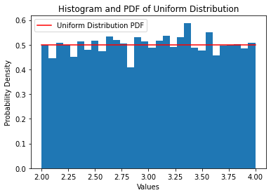

```python
import numpy as np
import matplotlib.pyplot as plt

# Tạo mẫu gồm 5000 giá trị ngẫu nhiên có phân phối đều trên đoạn [2, 4]
sample = np.random.uniform(low=2, high=4, size=5000)

# Vẽ biểu đồ histogram cùng với hàm mật độ
fig, ax = plt.subplots()
n, bins, patches = ax.hist(sample, density=True, bins=30)

# Vẽ hàm mật độ
x = np.linspace(2, 4, 1000)
y = np.ones_like(x) * 1 / (4 - 2)  # Hàm mật độ của phân phối đều
ax.plot(x, y, label='Uniform Distribution PDF', color='red')

ax.set_xlabel('Values')
ax.set_ylabel('Probability Density')
ax.set_title('Histogram and PDF of Uniform Distribution')
ax.legend()

plt.show()
```

**Ví dụ** $\,\,$ Thời gian thi đấu của mỗi trận đấu trong một giải bóng chày diễn ra vào năm 2011 là biến ngẫu nhiên có phân phối đều trên khoảng $(427\text{giờ}, 521\text{giờ})$.

a) Tính xác suất để một trận đấu được chọn ngẫu nhiên có thời gian thi đấu trong khoảng $(480\text{giờ}, 500\text{giờ})$.

b) Xác định trung bình và độ lệch chuẩn của thời gian thi đấu của mỗi trận đấu thuộc giải đó.

**Ví dụ** $\,\,$ Bộ phận chăm sóc khách hàng của một công ty sản suất máy điều hòa nhận thấy rằng thời gian $X$ cần thiết để giải quyết xong một yêu cầu bảo hành của khách hàng là biến ngẫu nhiên có phân bố đều trong khoảng từ $1,5$ giờ đến $4$ giờ.

a) Tìm xác suất để một yêu cầu bảo hành được xử lý xong trong khoảng thời gian lớn hơn $2$ giờ.

b) Tìm xác suất để một yêu cầu bảo hành được xử lý xong trong khoảng thời gian ít hơn $3$ giờ.

c) Tính kỳ vọng và độ lệch chuẩn của $X$.

#### Phân phối chuẩn (The normal distribution)

Phân phối chuẩn (Normal distribution) là phân phối quan trọng nhất trong xác suất và thống kê. Phân phối chuẩn được nêu ra bởi một người Anh gốc Pháp tên là Abraham de Moivre (1733). Sau đó, Gauss, một nhà toán học ngưới Đức, đã dùng phân phối chuẩn để nghiên cứu các dữ liệu về thiên văn học (1809) và do vậy nó cũng được gọi là **phân phối Gauss**.

$\hspace{5cm}$

[figure not shown]

- Một biến ngẫu nhiên liên tục $X$ được gọi là có **phân phối chuẩn** nếu hàm mật độ của nó cho bởi $$ f_X(x) = \frac{1}{\sqrt{2\pi}}e^{-\frac{(x-\mu)^2}{2\sigma^2}}, $$ $\qquad$ với $\mu \in \mathbb{R}$ và $\sigma > 0$ là hai hằng số cho trước. Khi đó, ta ký hiệu $X \sim N(\mu, \sigma^2)$.
- Nếu $X \sim N(\mu, \sigma^2)$ thì ta có $E(X) = \mu$ và $Var(X) = \sigma^2$.
- Hình dạng và vị trí của đường cong phân phối chuẩn (đồ thị của hàm pdf) phụ thuộc vào hai tham số $µ$ và $σ$.

$\hspace{2cm}$

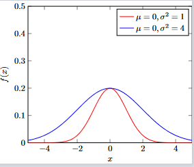

$\hspace{1cm}$

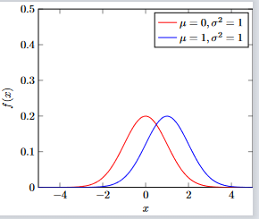

$\hspace{5cm}$

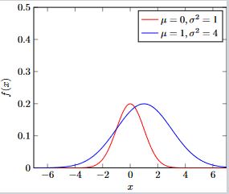

**Một số tính chất của phân phối chuẩn**

- Kỳ vọng và trung vị bằng nhau
- Đồ thị của hàm mật độ xác suất có hình chuông, đối xứng qua đường thẳng $x= \mu$
- Diện tích phần phía dưới đường cong (trên trục hoành) trong đoạn $[\mu-\sigma, \mu+\sigma]$ có giá trị xấp xỉ $0,68$; trong đoạn $[\mu-2\sigma, \mu+2\sigma]$ có giá trị xấp xỉ $0,95$; trong đoạn $[\mu-3\sigma, \mu+3\sigma]$ có giá trị xấp xỉ $0,997$.

$\hspace{2cm}$

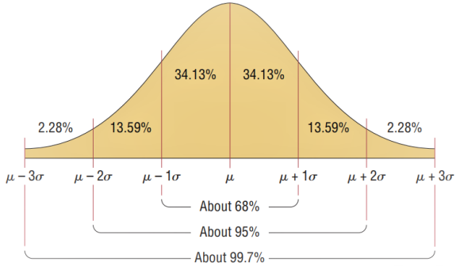

**Chú ý:**

- Phân phối chuẩn $N(0, 1)$ được gọi là **phân phối chuẩn chuẩn tắc**. Hàm mật độ xác suất và hàm phân phối xác suất tích lũy của phân phối chuẩn chuẩn tắc cho bởi $$ f(z) = \frac{1}{\sqrt{2\pi}}e^{-\frac{z^2}{2}} \quad \text{and} \quad \Phi(z) = \frac{1}{\sqrt{2\pi}}\int_{-\infty}^z e^{-\frac{t^2}{2}} dt. $$
- Nếu $X \sim N(\mu, \sigma^2)$ thì $\displaystyle Z = \frac{X-\mu}{\sigma} \sim N(0, 1)$.

**Ví dụ:** $\,\,$ Cho biến ngẫu nhiên $X$ có phân phối chuẩn chuẩn tắc

- Tính $P(X \leq 1,35)$
- Tính $P(-1,37 \leq X \leq 1,68)$

**Giải** $$ P(X \leq 1,35) = \Phi(1,35) = \frac{1}{\sqrt{2\pi}}\int_{-\infty}^{1,35} e^{-x^2/2}dx = 0,91149 $$ $$ P(-1,37 \leq X \leq 1,68) = \Phi(1,68) - \Phi(-1,37) = 0,95352 - 0,08534 \approx 0,87 $$

**Ví dụ:** $\,\,$ Giả sử thu nhập của các gia đình trong một tháng của một quốc gia có phân phối chuẩn với trung bình là 900$ và độ lệch chuẩn là 200$. Chọn ngẫu nhiên một gia đình.

- Tính xác suất gia đình này có thu nhập từ 600$ đến 1200$.
- Chính phủ sẽ trợ cấp cho 0,3% gia đình có mức thu nhập thấp nhất. Hỏi các gia đình này có thu nhập nhiều nhất là bao nhiêu đôla?

**Ví dụ:** $\,\,$ Một thành phố lắp đặt đèn điện để chiếu sáng đường. Loại đèn này có tuổi thọ trung bình là 1000 giờ với độ lệch chuẩn là 200 giờ. Giả sử tuổi thọ của loại đèn này có phân phối chuẩn.

- Tính xác suất đèn này bị hỏng trong 700 giờ
- Tính xác suất đèn sử dụng được từ 900 giờ đến 1300 giờ.
- Sau bao lâu thì còn 10% đèn sử dụng được?

**Ví dụ:** $\,\,$ Các nghiên cứu cho thấy quãng đường các loại xe ôtô cỡ nhỏ chạy được với 1 lít xăng có phân phối chuẩn với trung bình là 15,1 km/lít và độ lệch chuẩn là 1,92 km/lít.

- Có bao nhiêu phần trăm xe cỡ nhỏ chạy được nhiều hơn 17 km/lít?
- Các xe tiết kiệm xăng nhất chiếm 7,15%. Quãng đường mà những xe này chạy với 1 lít xăng ít nhất là bao nhiêu?

#### Phân phối Chi-bình phương

**Hàm Gamma** $\,\,$ Cho $\alpha > 0$. Ta định nghĩa $$ \Gamma(\alpha) = \int_0^\infty x^{\alpha-1}e^{-x}dx $$ Hàm $\Gamma$ có các tính chất sau

- Với $\alpha > 1$ ta có $\Gamma(\alpha) = (\alpha-1)\Gamma(\alpha-1)$
- Nếu $n$ là một số nguyên thì $\Gamma(n) = n!$
- $\Gamma(0,5) = \sqrt{\pi}$

**Phân phối Chi-bình phương**

Cho $\nu$ là một số nguyên dương. Một biến ngẫu nhiên liên tục $X$ được gọi là có phân phối *Chi-bình phương* với tham số $\nu$ nếu hàm mật độ xác suất của $X$ có dạng $$ f_X(x) = \begin{cases} 0, & x < 0 \\ \frac{1}{2^{\nu/2}\Gamma(\nu/2)}x^{\nu/2-1}e^{-x/2}, & x \geq 0. \end{cases} $$ Khi đó ta ký hiệu $X \sim \chi^2(\nu)$. Tham số $\nu$ được gọi là bậc tự do của $X$.

**Mệnh đề**

Nếu các biến ngẫu nhiên $X_i ∼ N(0; 1) \,\, (1 ≤ i ≤ n)$ độc lâp thì biến ngẫu nhiên $$ Y = X^2_1 + X^2_2 + · · · + X_n^2 $$ có phân phối **chi-bình phương** với bậc tự do là $n$.

#### Phân phối Student

Cho $X$ là một biến ngẫu nhiên liên tục. Nếu hàm mật độ của $X$ có dạng $$ f(x) = \frac{\Gamma(\frac{n+1}{2})}{\sqrt{n\pi}.\Gamma(\frac{n}{2})}\Big(1 + \frac{x^2}{n}\Big)^{-\frac{n+1}{2}} $$ với $n > 0$ là một số nguyên, thì ta nói $X$ có phân phối student với $n-1$ bậc tự do. Ký hiệu $$ X \sim \frac{N(0,1)}{\sqrt{\chi^2_n/n}}. $$

Phân phối Student sẽ được dùng trong việc ước lượng khoảng của trung bình trong chương 5.

#### Phân phối Fisher (F-distribution)

Cho hai biến ngẫu nhiên độc lập $X$ và $Y$ có phân phối $\chi^2$ với các tham số lần lượt là $\nu_1$ và $\nu_2$. Khi đó biến ngẫu nhiên $$ Z = \frac{X/\nu_1}{Y/\nu_2} $$ được gọi là có phân phối Fisher với $\nu_1, \nu_2$ bậc tự do.

#### Hàm đặc trưng

**Định nghĩa:** $\,\,$ Cho $X$ là một biến ngẫu nhiên. Hàm đặc trưng của $X$ là hàm $\phi_X : \mathbb{R} \to \mathbb{C}$ được xác định bởi

- Nếu $X$ là rời rạc với các giá trị là $x_1, x_2, \ldots$ thì $$ \phi_X(t) = \sum_{k \geq 1}e^{ix_kt}P(X = x_k) $$
- Nếu $X$ là liên tục với hàm mật độ xác suất là $f(x)$ thì $$ \phi_X(t) = \int_{-\infty}^\infty e^{ixt}f(x)dx $$ Lưu ý rằng $e^{ixt} = \cos(xt) + i\sin(xt)$ và $i^2 = -1$.

**Chú ý** Phân phối của một biến ngẫu nhiên có thể được xác định hoàn toàn thông qua hàm đặc trưng của nó.

[figure not shown]